# EC 525 Project 1

Oregon Health Plan

Tom Ben-Shahar

2025-04-22

# 1) Treatment vs. Utilization

The `treatment` variable indicates whether an individual was offered treatment. The `ohp_all_ever_survey` variable indicates whether an individual was ever enrolled in medicaid. One can be in either group with or without also being in the other group. That is to say that untreated individuals may also access medicaid, and treated individuals may not access medicaid. `treatment` can also be described as “intent to treat,” as it is the variable assigned randomly and used in our experimental setting.

# 2-3) Balance Table

```
## NOTE: 1 observation removed because of NA values (LHS: 1).
```

```
## NOTE: 11 observations removed because of NA values (LHS: 11).
```

```
## NOTE: 29 observations removed because of NA values (LHS: 29).
```

```
## NOTE: 39 observations removed because of NA values (LHS: 39).
## NOTE: 39 observations removed because of NA values (LHS: 39).
```

Balance Table

|  | (Intercept) | treatment |
| --- | --- | --- |
| age_inp | 40.606*** | 0.380+ |
|  | (0.153) | (0.212) |
| dep_dx_pre_lottery | 0.350*** | -0.018* |
|  | (0.006) | (0.009) |
| dia_dx_pre_lottery | 0.072*** | -0.001 |
|  | (0.003) | (0.005) |
| edu_inp | 2.238*** | 0.022 |
|  | (0.012) | (0.016) |
| hbp_dx_pre_lottery | 0.183*** | -0.001 |
|  | (0.005) | (0.007) |
| hispanic_inp | 0.178*** | 0.005 |
|  | (0.005) | (0.007) |
| numhh_list | 1.196*** | 0.093*** |
|  | (0.005) | (0.008) |
| race_black_inp | 0.107*** | -0.008 |
|  | (0.004) | (0.006) |
| race_white_inp | 0.690*** | -0.003 |
|  | (0.006) | (0.008) |

+ p < 0.1, * p < 0.05, ** p < 0.01, *** p < 0.001

# 4) Compliance

|  | *Dependent variable:* |
| --- | --- |
|  | ohp_all_ever_survey |
| treatment | 0.254*** |
|  | (0.008) |
| Constant | 0.158*** |
|  | (0.005) |
| Observations | 12,229 |
| R<sup>2</sup> | 0.078 |
| Adjusted R<sup>2</sup> | 0.078 |
| Residual Std. Error | 0.436 (df = 12227) |
| F Statistic | 1,031.581*** (df = 1; 12227) |
| *Note:* | p<0.1; p<0.05; p<0.01 |

Treatment has an effect significant at the 1% level. Medicaid enrollment increases by 25pp in the treated group compared to the control group.

# 5) ITT Effect

```
## NOTE: 134 observations removed because of NA values (LHS: 134).
```

```
## NOTE: 43 observations removed because of NA values (LHS: 43).
```

```
## NOTE: 71 observations removed because of NA values (LHS: 71).
```

```
## NOTE: 284 observations removed because of NA values (LHS: 284).
```

```
## NOTE: 41 observations removed because of NA values (LHS: 41).
```

ITT Effects

|  | Depression Dx | Diabetes Dx | Doctors Visits | High BP Dx | BP Average |
| --- | --- | --- | --- | --- | --- |
| (Intercept) | 0.049*** | 0.012*** | 5.746*** | 0.057*** | 119.130*** |
|  | (0.003) | (0.001) | (0.155) | (0.003) | (0.219) |
| treatment | 0.005 | 0.009*** | 0.396+ | 0.002 | -0.058 |
|  | (0.004) | (0.002) | (0.216) | (0.004) | (0.300) |
| Num.Obs. | 12095 | 12186 | 12158 | 11945 | 12188 |
| R2 | 0.000 | 0.001 | 0.000 | 0.000 | 0.000 |
| R2 Adj. | 0.000 | 0.001 | 0.000 | -0.000 | -0.000 |
| AIC | -2186.6 | -15650.5 | 94713.6 | -787.4 | 102998.4 |
| BIC | -2171.8 | -15635.7 | 94728.4 | -772.6 | 103013.2 |
| RMSE | 0.22 | 0.13 | 11.89 | 0.23 | 16.55 |
| Std.Errors | Heteroskedasticity-robust | Heteroskedasticity-robust | Heteroskedasticity-robust | Heteroskedasticity-robust | Heteroskedasticity-robust |

+ p < 0.1, * p < 0.05, ** p < 0.01, *** p < 0.001

# 6) Model Comparison

Health outcomes are each measured in different units, so they must be normalized before comparison.

Because only two variables show a significant treatment effect, it is only necessary to compare those two to one another.

```
## NOTE: 134 observations removed because of NA values (LHS: 134).
```

```
## NOTE: 43 observations removed because of NA values (LHS: 43).
```

```
## NOTE: 71 observations removed because of NA values (LHS: 71).
```

```
## NOTE: 284 observations removed because of NA values (LHS: 284).
```

```
## NOTE: 41 observations removed because of NA values (LHS: 41).
```

ITT Effects, Normalized

|  | Depression Dx | Diabetes Dx | Doctors Visits | High BP Dx | BP Average |
| --- | --- | --- | --- | --- | --- |
| (Intercept) | -0.011 | -0.035** | -0.017 | -0.005 | 0.002 |
|  | (0.013) | (0.011) | (0.013) | (0.013) | (0.013) |
| treatment | 0.021 | 0.068*** | 0.033+ | 0.010 | -0.004 |
|  | (0.018) | (0.018) | (0.018) | (0.018) | (0.018) |
| Num.Obs. | 12095 | 12186 | 12158 | 11945 | 12188 |
| R2 | 0.000 | 0.001 | 0.000 | 0.000 | 0.000 |
| R2 Adj. | 0.000 | 0.001 | 0.000 | -0.000 | -0.000 |
| AIC | 34325.8 | 34571.5 | 34502.6 | 33901.1 | 34591.0 |
| BIC | 34340.6 | 34586.3 | 34517.4 | 33915.9 | 34605.8 |
| RMSE | 1.00 | 1.00 | 1.00 | 1.00 | 1.00 |
| Std.Errors | Heteroskedasticity-robust | Heteroskedasticity-robust | Heteroskedasticity-robust | Heteroskedasticity-robust | Heteroskedasticity-robust |

+ p < 0.1, * p < 0.05, ** p < 0.01, *** p < 0.001

```
## Linear hypothesis test (Theil's F test)
##
## Hypothesis:
## dia_treatment - doc_treatment = 0
##
## Model 1: restricted model
## Model 2: sur_model
##
##   Res.Df Df      F Pr(>F)
## 1  24341
## 2  24340  1 1.8706 0.1714
```

While I am struggling to interpret the output of the `linearHypothesis` function, it appears to suggest a p value of $p = 0.1714$. This fails to reject the null hypothesis that both effects are equivalent. In other words, this suggests that the ITT effect on diabetes diagnoses and doctors visits are statistically indistinguishable from one another.

# 7) Coefficient Plots

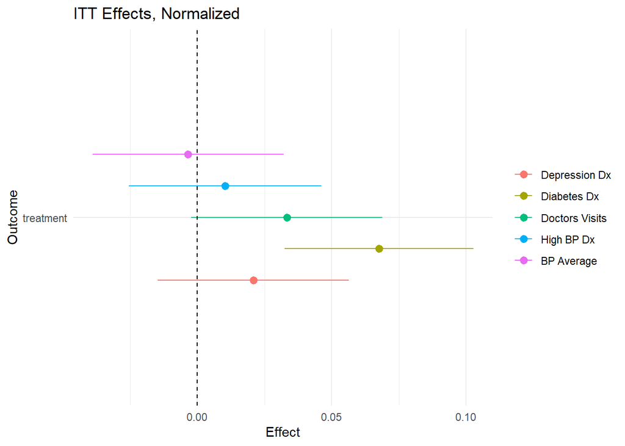

# 8) ATET

Average Treatment Effect on the Treated (ATET) is the treatment effect divided by the compliance rate, giving the effect of treatment on compliant individuals. This prevents the treatment effect from being “watered down” by individuals who did not accept treatment. Estimates are normalized.

|  | x |
| --- | --- |
| Depression Dx | 0.0826772 |
| Diabetes Dx | 0.2677165 |
| Doctor Visits | 0.1299213 |
| High BP Dx | 0.0393701 |
| BP Average | -0.0157480 |

# 9) Attrition

Attrition bias can occur if attrition is systematically different among treatment and control groups. This is important to watch for in a study of this nature. For example, if every unhealthy person in the control group dies before the final survey, then this can give the impression that outcomes for individuals in the control group improve. To know if attrition bias is a concern, we would need to perform some analysis comparing individuals who appear in the final survey with those who do not.

# 10) Abstract